# Diccionarios

## Datos Simples y Compuestos

**Datos Simples:** entero (int), los números de punto flotante (float) y los valores booleanos (boolean).

**Datos Compuestos:** comprenden aquellos datos con elementos de valores de un mismo tipo o de diferentes tipos, que se representan unificados para ser guardados o procesados. Ejemplos de ellos son cadenas de caracteres (string), listas, tuplas, diccionarios.

## Datos inmutables y mutables

Las secuencias de datos pueden ser inmutables o pueden ser mutables.

• Una secuencia de datos inmutable es un conjunto finito de datos cuyos valores y orden de aparición no pueden modificarse una vez asignados, como por ejemplo los string.

Al querer acceder a un miembro de la cadena "candidato" podemos hacerlo.

```python
cadena = "candidato"
cadena[0]
```

```
'c'
```

Sin embargo, al querer modificar un miembro por otro, no podemos hacerlo y esto generará un error.

```python
cadena[0]= 'C'
```

```
---------------------------------------------------------------------------
TypeError                                 Traceback (most recent call last)
<ipython-input-30-b374b2e3c5a2> in <module>
----> 1 cadena[0]= 'C'

TypeError: 'str' object does not support item assignment
```

• Las secuencias de datos mutables son aquellas secuencias en las que los valores individuales pueden modificarse luego de ser asignados, como por ejemplo las listas.

```python
lista = ['presidente','senador','diputado','consejal']
lista[0] = 'ministro'
print(lista)
```

```
['ministro', 'senador', 'diputado', 'consejal']
```

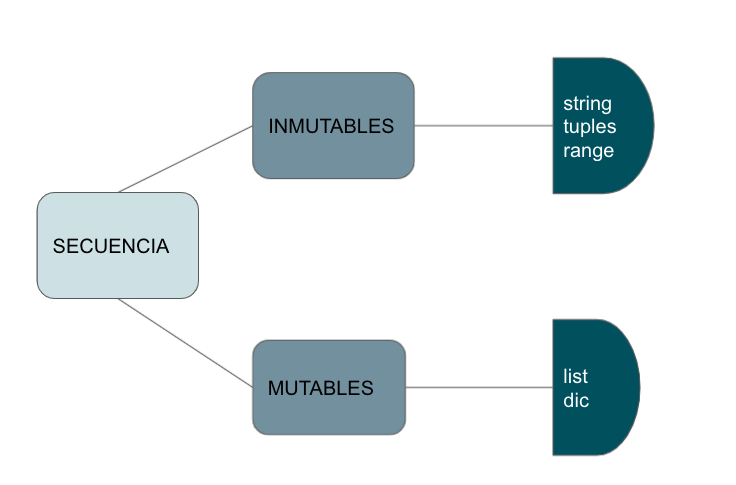

## Diccionarios

Un diccionario es una lista no ordenada de términos (clave – valor), lo que denominaremos pares. Para cada uno de los términos incluidos en el diccionario se pueden definir distintos valores asociados.

Al igual que las listas, los diccionarios son mutables, es decir podemos agregar, quitar o modificar los elementos del diccionario en tiempo de ejecución. Los diccionarios pueden estar contenidos en listas y viceversa.

La principal diferencia con las listas es que accedemos a los elementos de los diccionarios mediante claves y no a través de su posición. Podemos decir que un diccionario es una matriz asociativa (también conocida como hash). Cualquier clave del diccionario está asociada (o mapeada) a un valor. Los valores de un diccionario pueden ser cualquier tipo de datos de Python (enteros, listas, cadenas, tuplas, otros diccionarios, etc).

Las claves son únicas dentro de un diccionario, mientras que los valores pueden no serlo. Los valores de un diccionario pueden ser de cualquier tipo, pero las claves deben ser de un tipo de datos inmutable, como cadenas, números o tuplas.

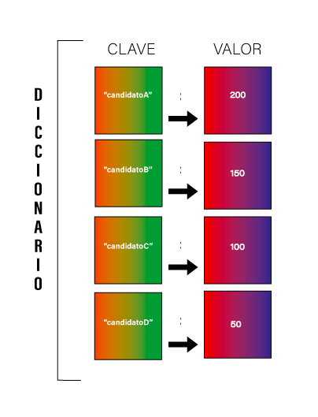

## Más sobre Diccionarios

A - No se permite más de una entrada por clave. Esto significa que no se permiten claves duplicadas. Cuando se encuentran claves duplicadas durante la asignación, la última asignación pisa la anterior.

```python
diccionario_err = {'Uno': '1', 'Dos': 2, 'Uno': 1}
diccionario_err['Uno']
```

```
1
```

B - Las claves deben ser inmutables. Esto significa que puede usar cadenas, números o tuplas como claves de diccionario.

```python
diccionario_err = {['Uno']: '1', 'Dos': 2, 'Tres': 3}
```

```
---------------------------------------------------------------------------
TypeError                                 Traceback (most recent call last)
<ipython-input-2-dfd3621702c4> in <module>
----> 1 diccionario_err = {['Uno']: '1', 'Dos': 2, 'Tres': 3}

TypeError: unhashable type: 'list'
```

## Creación de un Diccionario

### Método 1: Explícito

```python
votos = {"candidatoA" : 200, "candidatoB" : 150, "candidatoC" : 100, "candidatoD" : 50}
print(votos)
```

```
{'candidatoA': 200, 'candidatoB': 150, 'candidatoC': 100, 'candidatoD': 50}
```

### Método 2: A partir de un diccionario vacío

```python
votos = {}
votos["candidatoA"] = 200
votos["candidatoB"] = 150
votos["candidatoC"] = 100
votos["candidatoD"] = 50
print(votos)
```

```
{'candidatoA': 200, 'candidatoB': 150, 'candidatoC': 100, 'candidatoD': 50}
```

### Método 3: A partir de la función zip()

```python
keys = ['candidatoA','candidatoB','candidatoC','candidatoD']
values = [200,150,100,50]
votos = dict(zip(keys,values))
print(votos)
#Observemos que tanto keys o values son dos listas que juntas, a partir de la función zip(), forman un diccionario
```

```
{'candidatoA': 200, 'candidatoB': 150, 'candidatoC': 100, 'candidatoD': 50}
```

## Acceder a los valores y claves de un diccionario

Debido a que los diccionarios son colecciones de pares (clave-valor) no podemos acceder a un elemento empleando un índice numérico como lo hacemos con las listas o las tuplas. Para acceder a un valor usamos la clave a la que le hemos asignado un valor

```python
print(votos[1]) # Error
```

```
---------------------------------------------------------------------------
KeyError                                  Traceback (most recent call last)
<ipython-input-26-ff9f4a0b09c1> in <module>
----> 1 print(votos[1])

KeyError: 1
```

## Acceder a los valores y claves de un diccionario

```python
print(votos.get("candidatoA"))
```

```
200
```

### Obtener claves

Usamos el método keys()

```python
print(votos.keys())
```

```
dict_keys(['candidatoA', 'candidatoB', 'candidatoC', 'candidatoD'])
```

### Obtener valores

Usamos el método values()

```python
print(votos.values())
```

```
dict_values([200, 150, 100, 50])
```

### Obtener claves y valores

```python
Usamos el método items()
```

```python
print(votos.items())
```

```
dict_items([('candidatoA', 200), ('candidatoB', 150), ('candidatoC', 100), ('candidatoD', 50)])
```

## ¿ Qué pasa si la clave no está?

```python
print(votos["candidatoZ"]) #Obtenemos un error y nuestro programa no podrá continuar.
```

```
---------------------------------------------------------------------------
KeyError                                  Traceback (most recent call last)
<ipython-input-16-1bbe7d84aa70> in <module>
----> 1 print(votos["candidatoZ"])

KeyError: 'candidatoZ'
```

### Salvando el error

Con un condicional (lo veremos más adelante en profundidad) podremos salvar el error y seguir ejecutando nuestro programa

```python
if "candidatoZ" in votos:
    print("candidato Z encontrado")
else:
    print("Ese candidato no existe")
```

```
Ese candidato no existe
```

Otra forma de salvar el error es utilizar el método get()

```python
print(votos.get("candidatoZ","No existe ese candidato"))
#Observamos detenidamente la función get().
#La misma toma dos parámentros Primero la clave buscada y si existe devolverá el valor de dicha clave.
#Si la clave no existe, devolvéra la cadena indicada. En este caso "No existe ese candidato"
```

```
No existe ese candidato
```

```python
print(votos.get("candidatoA","No existe ese candidato"))
#Aquí se encontró la clave "candidatoA" y obtuvimos su clave que es 200.
```

```
200
```

## Modificar un elemento

```python
votos['candidatoB'] = 20
print(votos.items())
```

```
dict_items([('candidatoA', 200), ('candidatoB', 20), ('candidatoC', 100), ('candidatoD', 50)])
```

Observemos como el valor de la clave 'candidatoB' fue modificada

## Eliminar un elemento

Utilizamos la declaración **del**

```python
del votos['candidatoC']
print(votos.items())
```

```
dict_items([('candidatoA', 200), ('candidatoB', 20), ('candidatoD', 50)])
```

También podemos utilizar el método pop(). El mismo nos devuelve el valor de la clave eliminada.

```python
print(votos.pop('candidatoA'))
```

```
200
```

## Diccionarios Anidados

Podemos almacenar dentro de un diccionario otro diccionario. En este caso, cada valor asociado a una clave es en sí mismo un diccionario.

```python
Candidatos = {
  "CandidatoA" : {
    "nombre" : "Tony",
    "apellido": "Blair",
    "anio" : 1953
  },
  "CandidatoB" : {
    "nombre" : "William",
    "apellido": "Hague",
    "anio" : 1961
  },
  "CandidatoC" : {
    "nombre" : "Charles",
    "apellido": "Kennedy",
    "anio" : 1959
  }
}
```

Para acceder al valor de una de las claves de un diccionario interno, se usa el operador de indexación anidada [clave1][clave2]

```python
print(Candidatos['CandidatoA']['nombre'])
```

```
Tony
```

## Métodos de los diccionarios

Existen varios métodos aplicables a diccionarios

dict.clear (): Elimina todos los elementos del diccionario dict

dict.copy (): Devuelve una copia superficial del diccionario dict

dict.fromkeys (): Cree un nuevo diccionario con claves de seq y valores establecidos en value .

dict.get (clave, predeterminado = Ninguno): Para clave clave, devuelve valor o predeterminado si la clave no está en el diccionario

dict.items (): Devuelve una lista de pares de tuplas de dict (clave, valor)

dict.keys (): Devuelve la lista de claves del diccionario dict

dict.setdefault (clave, predeterminado = Ninguno): Similar a get (), pero establecerá dict [clave] = predeterminado si la clave no está ya en dict

dict.update (dict2): Agrega pares clave-valor del diccionario dict2 a dict

dict.values (): Devuelve la lista de valores de diccionario dic